# Mouse E18 brain data analysis

Michal Kabza and Tim Sterne-Weiler

Roche Informatics, F. Hoffmann-La Roche Ltd., Poznań, Poland  
Department of Oncology Bioinformatics, Genentech Inc., South San Francisco, USA  
Department of Discovery Oncology, Genentech Inc., South San Francisco, USA

michal.kabza@contractors.roche.com  
sternewt@gene.com

5 December 2024

#### Package

Isosceles 0.2.1

# 1 Introduction

This vignette demonstrates how Isosceles can be used to identify isoforms and PSI events showing differences in expression along or between different cell lineages or trajectories. The analysis is based on mouse E18 brain scRNA-Seq data from the Lebrigand et al. 2020 paper - all the details regarding how the data was processed can be found in the `mouse_E18_analysis` directory of the Isosceles_Paper repository.

Load the required packages:

```r
library(Isosceles)
library(dplyr)
library(tidyr)
library(tibble)
library(ggplot2)
library(scuttle)
library(DEXSeq)
library(RColorBrewer)
library(pheatmap)
library(dittoSeq)
library(Nebulosa)
```

# 2 Data exploration

Load the Isosceles TCC SummarizedExperiment object:

```r
se_tcc <- readRDS(system.file(
    "extdata", "se_tcc_mouse_e18.rds",
    package = "Isosceles"
))
```

Load the processed SingleCellExperiment objects (containing normalized data, UMAP coordinates etc.):

```r
sce_gene <- readRDS(system.file(
    "extdata", "sce_gene_mouse_e18.rds",
    package = "Isosceles"
))
sce_transcript <- readRDS(system.file(
    "extdata", "sce_transcript_mouse_e18.rds",
    package = "Isosceles"
))
sce_psi <- readRDS(system.file(
    "extdata", "sce_psi_mouse_e18.rds",
    package = "Isosceles"
))
```

Load the matrix pf pseudotime values for individual trajectories calculated using the Slingshot package:

```r
pseudotime_matrix <- readRDS(system.file(
    "extdata", "pseudotime_matrix_mouse_e18.rds", package = "Isosceles"
))
head(pseudotime_matrix)
```

```
##                              glut_1   glut_2     gaba rad_glia cyc_rad_glia cr
## 951_cells.AACTCAGAGCGTGAAC       NA       NA       NA       NA     30.40207 NA
## 951_cells.AACTCCCTCCGAGCCA       NA       NA 69.05360       NA           NA NA
## 951_cells.AACTCTTTCTTTACGT       NA       NA 69.25377       NA           NA NA
## 951_cells.AAGACCTGTGTGCGTC       NA       NA 70.40337       NA           NA NA
## 951_cells.AAGACCTTCGGTTAAC       NA       NA 73.85786       NA           NA NA
## 951_cells.ACACTGAGTCTCCACT 7.096513 6.642328       NA       NA           NA NA
```

This dataset contains the following cell types and trajectories, shown on the UMAP plot below:

- Glutamatergic neuron lineage with two trajectories starting from the same progenitor cells:
  - Trajectory 1 (glut_1, clusters glut.4, glut.8, glut.5 and glut.7)
  - Trajectory 2 (glut_2, clusters glut.4, glut.11 and glut.9)
- GABAergic neuron trajectory (gaba, clusters gaba.2 and gaba.3)
- Radial glia (rad_glia, cluster rad_glia.6)
- Cycling radial glia (cyc_rad_glia, cluster cyc_rad_glia.1)
- Cajal-Retzius cells (cr, cluster cr.10)

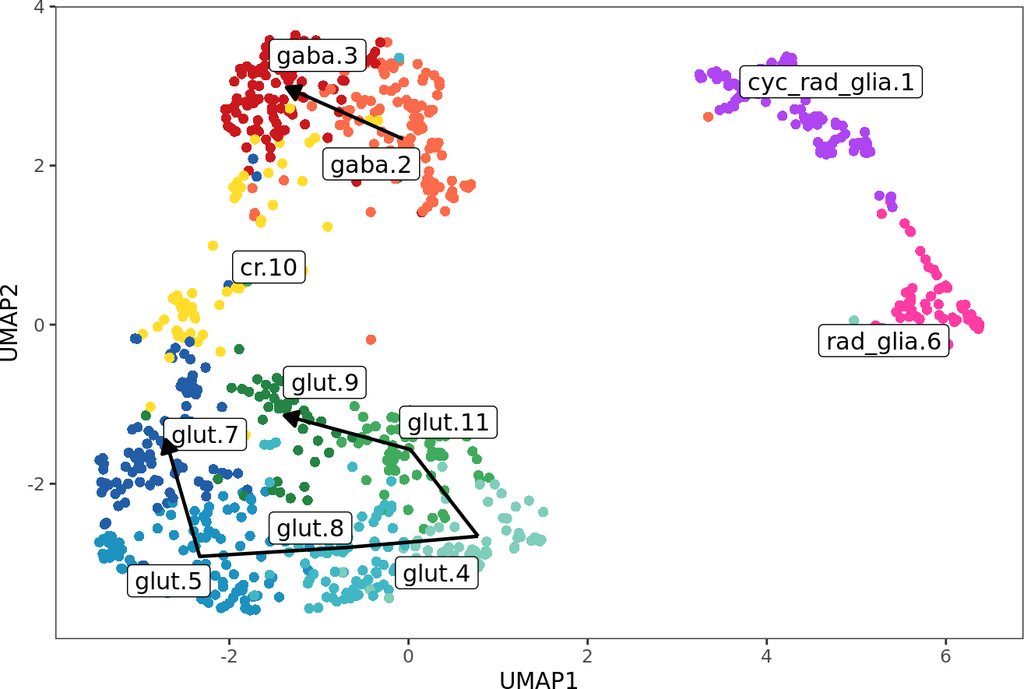

```r
cluster_colors <- c(
    glut.4 = brewer.pal(n = 7, name = "YlGnBu")[3],
    glut.8 = brewer.pal(n = 7, name = "YlGnBu")[4],
    glut.5 = brewer.pal(n = 7, name = "YlGnBu")[5],
    glut.7 = brewer.pal(n = 7, name = "YlGnBu")[6],
    glut.11 = brewer.pal(n = 7, name = "YlGn")[5],
    glut.9 = brewer.pal(n = 7, name = "YlGn")[6],
    gaba.2 = brewer.pal(n = 7, name = "Reds")[4],
    gaba.3 = brewer.pal(n = 7, name = "Reds")[6],
    rad_glia.6 = colorRampPalette(c("white", "deeppink"))(7)[6],
    cyc_rad_glia.1 = colorRampPalette(c("white", "purple"))(7)[6],
    cr.10 = colorRampPalette(c("white", "gold"))(7)[6]
)
umap_df <- as.data.frame(reducedDim(sce_gene, "UMAP"))
colnames(umap_df) <- c("UMAP_1", "UMAP_2")
cluster_umap_df <- umap_df %>%
    mutate(cluster = sce_gene$cluster) %>%
    group_by(cluster) %>%
    summarise(
        UMAP_1 = mean(UMAP_1),
        UMAP_2 = mean(UMAP_2)
    )
umap_lineages <- list(
    glut_1 = c("glut.4", "glut.8", "glut.5", "glut.7"),
    glut_2 = c("glut.4", "glut.11", "glut.9"),
    gaba = c("gaba.2", "gaba.3")
)
lineage_umap_df <- umap_lineages %>%
    enframe() %>%
    unchop(value) %>%
    dplyr::rename(lineage = name, cluster = value) %>%
    left_join(cluster_umap_df)
set.seed(103)
dittoDimPlot(sce_gene, "cluster",
             reduction.use = "UMAP", main = "",
             size = 2, do.label = TRUE, labels.size = 4,
             labels.highlight = TRUE, legend.show = FALSE) +
    scale_colour_manual(values = cluster_colors) +
    geom_path(
        data = lineage_umap_df,
        size = 0.8,
        mapping = aes(x = UMAP_1, y = UMAP_2, group = lineage),
        arrow = arrow(ends = "last", type = "closed",
                      length = unit(0.1, "inches"))
    )
```

Cluster cell type identities have been established using the marker gene expression signatures from the Lebrigand et al. 2020 paper:

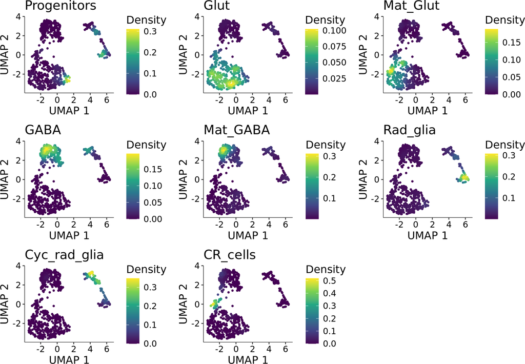

```r
marker_sets <- list(
    Progenitors = c("Neurog2", "Eomes"), # intermediate progenitors
    Glut = c("Neurod6", "Neurod2"), # glutamatergic
    Mat_Glut = c("Camk2b", "Opcml", "Crym"), # mature glutamatergic
    GABA = c("Gad2", "Gad1", "Dlx2"), # GABAergic
    Mat_GABA = c("Maf", "Mafb", "Arx"), # mature GABAergic
    Rad_glia = c("Fabp7", "Vim", "Dbi"), #radial glia
    Cyc_rad_glia = c("Cenpf", "Top2a", "Mki67"), # cycling radial glia
    CR_cells = c("Snhg11", "Lhx5", "Reln") # Cajal-Retzius cells
)
sce_gene_marker <- sce_gene
rownames(sce_gene_marker) <- make.unique(
    rowData(sce_gene_marker)$gene_name, sep = "@"
)
cell_marker_scores <- sumCountsAcrossFeatures(
    sce_gene_marker, marker_sets,
    exprs_values = "logcounts", average = TRUE
)
sce_gene_set <- SingleCellExperiment(
    assays = list(logcounts = cell_marker_scores),
    colData =  colData(sce_gene_marker)
)
reducedDim(sce_gene_set, "UMAP") <- reducedDim(sce_gene_marker, "UMAP")
plot_density(
    sce_gene_set,
    c("Progenitors", "Glut", "Mat_Glut", "GABA", "Mat_GABA",
      "Rad_glia", "Cyc_rad_glia", "CR_cells"),
    slot = "logcounts", size = 1
)
```

# 3 Isoform switching

Isosceles allows for easy detection of isoform switching events by comparing every pair of cell groups (e.g. clusters) and identifying transcripts of the same gene showing statistically significant differences in opposite directions:

```r
isoswitch_df <- find_isoswitch(
    se = sce_transcript,
    cell_labels = sce_transcript$cluster,
    min_fdr = 0.01
)
```

Print the isoform switching results:

```r
isoswitch_df
```

| transcript_id | compatible_tx | gene_id | gene_name | pvalue | fdr | auc | group_1 | group_2 | contrast |
| --- | --- | --- | --- | --- | --- | --- | --- | --- | --- |
| ISOT-e12f-e796-f779-02f2:s53428950:e53430850:AP:FL | ENSMUST00000109021 | ENSMUSG00000044894 | Uqcrq | 1.557705e-03 | 9.346228e-03 | 0.5802284 | cyc_rad_glia.1 | glut.7 | cyc_rad_glia.1__glut.7 |
| ISOT-a95f-eca5-43c1-1596:s53427900:e53430850:AP:FL | ENSMUST00000061326 | ENSMUSG00000044894 | Uqcrq | 4.089892e-04 | 2.044946e-03 | 0.6368189 | glut.7 | cyc_rad_glia.1 | cyc_rad_glia.1__glut.7 |
| ISOT-38de-9bd9-a644-0102:s118104350:e118116200:AP:FL | ENSMUST00000131374 | ENSMUSG00000008683 | Rps15a | 4.210778e-05 | 1.804619e-04 | 0.6519723 | gaba.2 | glut.5 | gaba.2__glut.5 |
| ISOT-b3ec-cd14-7493-316f:s118104350:e118115300:AP:FL | ENSMUST00000172457 | ENSMUSG00000008683 | Rps15a | 6.838954e-04 | 2.051686e-03 | 0.6166902 | glut.5 | gaba.2 | gaba.2__glut.5 |
| ISOT-3878-e373-f2c1-1c70:s27630400:e27635550:AP:FL | ENSMUST00000114882 | ENSMUSG00000024213,ENSMUSG00000117338,ENSMUSG00000052146 | Nudt3,Gm49804,Rps10 | 2.121495e-06 | 1.272897e-05 | 0.6777463 | gaba.2 | glut.5 | gaba.2__glut.5 |
| ISOT-74b2-d022-c18d-1096:s27579350:e27623500:AP:FL | ENSMUST00000025050 | ENSMUSG00000024213,ENSMUSG00000117338,ENSMUSG00000052146 | Nudt3,Gm49804,Rps10 | 3.227947e-04 | 1.075982e-03 | 0.5764969 | glut.5 | gaba.2 | gaba.2__glut.5 |
| ISOT-7614-5eb9-2ee3-fac7:s24490700:e24495850:AP:FL | ENSMUST00000169826 | ENSMUSG00000025290 | Rps24 | 4.082210e-06 | 2.041105e-05 | 0.6724030 | gaba.2 | glut.5 | gaba.2__glut.5 |
| ISOT-abb5-5bd6-dbbf-8287:s24490750:e24495850:AP:FL | ENSMUST00000224568 | ENSMUSG00000025290 | Rps24 | 8.199027e-06 | 4.919416e-05 | 0.6523652 | glut.5 | gaba.2 | gaba.2__glut.5 |
| ISOT-f4d6-77b8-79bb-b23c:s70508250:e70510600:AP:FL | ENSMUST00000125184 | ENSMUSG00000090137,ENSMUSG00000055553 | Uba52,Kxd1 | 3.057673e-07 | 2.293255e-06 | 0.6927550 | gaba.2 | glut.5 | gaba.2__glut.5 |
| ISOT-64e4-04e8-fd83-dac3:s70508250:e70510400:AP:FL | ENSMUST00000129909 | ENSMUSG00000090137,ENSMUSG00000055553 | Uba52,Kxd1 | 8.297239e-04 | 2.074310e-03 | 0.6098538 | glut.5 | gaba.2 | gaba.2__glut.5 |

[output cut: 25 more lines]

Plot the expression density the Clta gene and its transcripts involved in isoform switching:

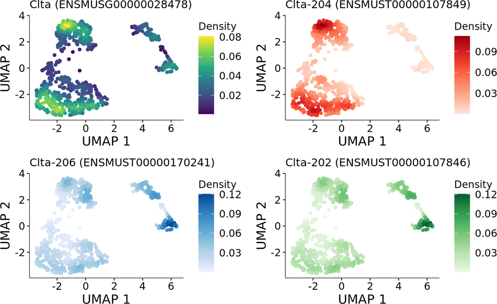

```r
p1 <- plot_density(
        sce_gene, "ENSMUSG00000028478",
        size = 1.5
    ) +
    labs(title = "Clta (ENSMUSG00000028478)") +
    theme(legend.position = "right",
          plot.title = element_text(size = 12),
          legend.title = element_text(size = 11))
p2 <- plot_density(
        sce_transcript,
        "ISOT-6683-8d1f-209c-002d:s44012650:e44032850:AP:FL",
        size = 1.5
    ) +
    scale_color_gradientn(colours = brewer.pal(n = 7, name = "Reds")) +
    labs(title = "Clta-204 (ENSMUST00000107849)") +
    theme(legend.position = "right",
          plot.title = element_text(size = 12),
          legend.title = element_text(size = 11))
p3 <- plot_density(
        sce_transcript,
        "ISOT-eeca-a52b-651e-905d:s44012600:e44032850:AP:FL",
        size = 1.5
    ) +
    scale_color_gradientn(colours = brewer.pal(n = 7, name = "Blues")) +
    labs(title = "Clta-206 (ENSMUST00000170241)") +
    theme(legend.position = "right",
          plot.title = element_text(size = 12),
          legend.title = element_text(size = 11))
p4 <- plot_density(
        sce_transcript,
        "ISOT-8a93-5996-c87a-8c5f:s44004450:e44032850:AP:FL",
        size = 1.5
    ) +
    scale_color_gradientn(colours = brewer.pal(n = 7, name = "Greens")) +
    labs(title = "Clta-202 (ENSMUST00000107846)") +
    theme(legend.position = "right",
          plot.title = element_text(size = 12),
          legend.title = element_text(size = 11))
(p1 + p2) / (p3 + p4)
```

# 4 DEXSeq analysis

Isosceles can also be used to aggregate PSI event counts at the pseudotime window level and create a DEXSeqDataSet object suitable for the analysis of their changes along a pseudotime trajectory (the workflow can be easily modified to allow for any method of cell aggregation or experiment design). Given the number of PSI events found in annotations, we recommend filtering them (e.g. by the number of cells showing signs of the event’s inclusion) - in this vignette we’ll restrict the analysis to the row names of the (already pre-filtered) `sce_psi` object. We can prepare a DEXSeqDataSet object for the glutamatergic trajectory 1 using the following commands:

```r
# Aggregate TCC values using moving window over pseudotime
se_window_tcc <- pseudotime_tcc(
    se_tcc = se_tcc,
    pseudotime = pseudotime_matrix[, "glut_1"],
    window_size = 30,
    window_step = 15
)
se_window_gene <- tcc_to_gene(
    se_tcc = se_window_tcc
)
se_window_transcript <- tcc_to_transcript(
    se_tcc = se_window_tcc,
    use_length_normalization = FALSE
)
se_window_psi <- transcript_to_psi(
    se = se_window_transcript,
)
se_window_psi <- add_psi_counts(
    se_psi = se_window_psi,
    se_gene = se_window_gene
)
# Prepare the DEXSeqDataSet object
window_pseudotime <- as.numeric(scale(se_window_psi$pseudotime))
dxd <- psi_to_dexseq(
    se_psi = se_window_psi,
    condition = window_pseudotime,
    psi_events = rownames(sce_psi)
)
```

Print the DEXSeqDataSet object:

```r
dxd
## class: DEXSeqDataSet
## dim: 30 42
## metadata(1): version
## assays(1): counts
## rownames(30): ENSMUSG00000002107:chr2:6664115-6664197:-:CE
##   ENSMUSG00000002107:chr2:6560659-6560670:-:A5 ...
##   ENSMUSG00000064302:chr1:118536135-118536197:+:CE
##   ENSMUSG00000070544:chr2:160715713-160715827:+:CE
## rowData names(4): featureID groupID exonBaseMean exonBaseVar
## colnames: NULL
## colData names(4): sample se_psi_colname condition exon
```

Standard DEXSeq workflow can be used for further analysis:

```r
dxd <- estimateSizeFactors(dxd)
dxd <- estimateDispersions(dxd)
dxd <- testForDEU(dxd)
dxd <- estimateExonFoldChanges(dxd, fitExpToVar = "condition")
```

Process the DEXSeq output to make it more readable:

```r
# Process the results of the DEXSeqResults function
dexseq_results_df <- DEXSeqResults(dxd) %>%
    as.data.frame() %>%
    dplyr::select(featureID, pvalue, padj) %>%
    transmute(
        psi_event = featureID,
        gene_id = sapply(strsplit(featureID, ":"), "[", 1),
        gene_name = rowData(sce_gene[gene_id,])$gene_name,
        pvalue = pvalue,
        fdr = padj
    )
rownames(dexseq_results_df) <- NULL
# Calculate the maximum absolute value of logFC across
# different pseudotime points
logFC_values <- as.data.frame(DEXSeqResults(dxd))
logFC_values <- logFC_values[, grepl("^log2fold_", colnames(logFC_values))]
logFC_values <- as.matrix(logFC_values)
max_abs_logFC <- apply(logFC_values, 1, function(x) {max(abs(x))})
max_abs_logFC[is.na(max_abs_logFC)] <- 0
names(max_abs_logFC) <- NULL
dexseq_results_df$max_abs_logFC <- max_abs_logFC
# Filter the DEXSeq results
dexseq_results_df <- filter(
    dexseq_results_df, fdr <= 0.05, max_abs_logFC >= 1
)
```

Print the DEXSeq results:

```r
dexseq_results_df
```

| psi_event | gene_id | gene_name | pvalue | fdr | max_abs_logFC |
| --- | --- | --- | --- | --- | --- |
| ENSMUSG00000002107:chr2:6664115-6664197:-:CE | ENSMUSG00000002107 | Celf2 | 1.968604e-03 | 3.937207e-03 | 9.217213 |
| ENSMUSG00000002107:chr2:6560659-6560670:-:A5 | ENSMUSG00000002107 | Celf2 | 8.120675e-05 | 4.060337e-04 | 5.095521 |
| ENSMUSG00000002107:chr2:6553965-6553982:-:A3 | ENSMUSG00000002107 | Celf2 | 1.177923e-02 | 1.963205e-02 | 2.073345 |
| ENSMUSG00000002107:chr2:6549832-6549975:-:CE | ENSMUSG00000002107 | Celf2 | 2.034581e-04 | 7.629677e-04 | 2.195901 |
| ENSMUSG00000002107:chr2:6546780-6547041:-:RI | ENSMUSG00000002107 | Celf2 | 6.541042e-10 | 1.962313e-08 | 4.281076 |
| ENSMUSG00000002107:chr2:6545676-6546779:-:A3 | ENSMUSG00000002107 | Celf2 | 1.480424e-07 | 1.480424e-06 | 3.929910 |
| ENSMUSG00000008489:chr4:91254141-91254179:-:CE | ENSMUSG00000008489 | Elavl2 | 1.135270e-07 | 1.480424e-06 | 9.974752 |
| ENSMUSG00000008682:chrX:74270875-74270978:+:RI | ENSMUSG00000008682 | Rpl10 | 3.219489e-05 | 1.952775e-04 | 3.187189 |
| ENSMUSG00000020358:chr11:51601479-51601749:-:RI | ENSMUSG00000020358 | Hnrnpab | 1.537856e-02 | 2.428194e-02 | 3.749398 |
| ENSMUSG00000021270:chr12:110693168-110693311:-:RI | ENSMUSG00000021270 | Hsp90aa1 | 2.841154e-03 | 5.013801e-03 | 1.977481 |

[output cut: 10 more lines]

Plot the expression density the Celf2 gene and the density of PSI values for its three selected PSI events significantly changing in the glutamatergic trajectory 1:

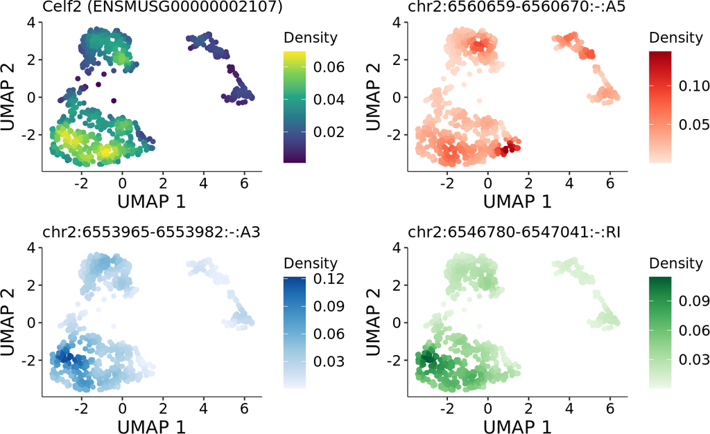

```r
p1 <- plot_density(
        sce_gene, "ENSMUSG00000002107",
        size = 1.5
    ) +
    labs(title = "Celf2 (ENSMUSG00000002107)") +
    theme(legend.position = "right",
          plot.title = element_text(size = 12),
          legend.title = element_text(size = 11))
p2 <- plot_density(
        sce_psi,
        "ENSMUSG00000002107:chr2:6560659-6560670:-:A5",
        slot = "psi",
        size = 1.5
    ) +
    scale_color_gradientn(colours = brewer.pal(n = 7, name = "Reds")) +
    labs(title = "chr2:6560659-6560670:-:A5") +
    theme(legend.position = "right",
          plot.title = element_text(size = 12),
          legend.title = element_text(size = 11))
p3 <- plot_density(
        sce_psi,
        "ENSMUSG00000002107:chr2:6553965-6553982:-:A3",
        slot = "psi",
        size = 1.5
    ) +
    scale_color_gradientn(colours = brewer.pal(n = 7, name = "Blues")) +
    labs(title = "chr2:6553965-6553982:-:A3") +
    theme(legend.position = "right",
          plot.title = element_text(size = 12),
          legend.title = element_text(size = 11))
p4 <- plot_density(
        sce_psi,
        "ENSMUSG00000002107:chr2:6546780-6547041:-:RI",
        slot = "psi",
        size = 1.5
    ) +
    scale_color_gradientn(colours = brewer.pal(n = 7, name = "Greens")) +
    labs(title = "chr2:6546780-6547041:-:RI") +
    theme(legend.position = "right",
          plot.title = element_text(size = 12),
          legend.title = element_text(size = 11))
(p1 + p2) / (p3 + p4)
```

```r
set.seed(100)
psi_ratio_matrix <- calculate_psi_ratio_matrix(
    se_tcc = se_tcc,
    pseudotime_matrix = pseudotime_matrix,
    psi_events = dexseq_results_df$psi_event,
    window_sizes = c(
        glut_1 = 100, glut_2 = 100, gaba = 100,
        rad_glia = 50, cyc_rad_glia = 50, cr = 50
    ),
    window_steps = c(
        glut_1 = 3, glut_2 = 3, gaba = 3,
        rad_glia = 3, cyc_rad_glia = 3, cr = 3
    ),
    n_perm = 10
)
```

Plot the PSI count ratio heatmap (trajectories are denoted using the same colors as in the trajectory UMAP plot in the *Data exploration* section):

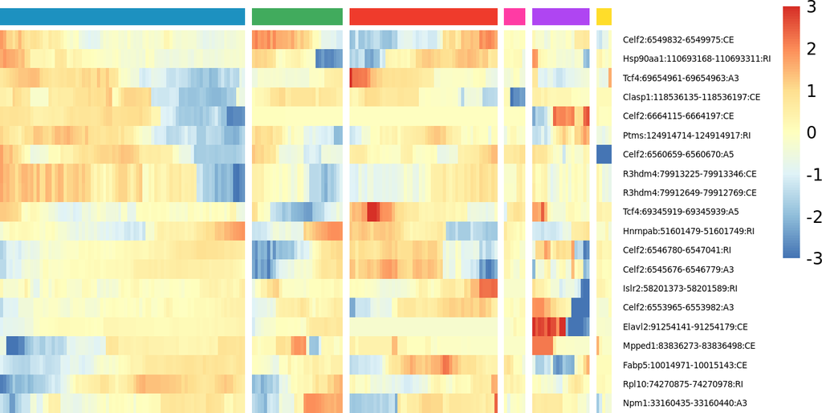

```r
# Prepare the heatmap values
heatmap_values <- log2(psi_ratio_matrix + 0.1)
heatmap_values[is.nan(heatmap_values)] <- 0
# Prepare heatmap annotations
heatmap_trajectory <- sapply(
    strsplit(colnames(heatmap_values), "\\."), "[", 1
)
heatmap_gap_positions <- cumsum(rle(heatmap_trajectory)$lengths)
col_ann_df <- data.frame(
    trajectory = heatmap_trajectory
)
rownames(col_ann_df) <- colnames(heatmap_values)
col_ann_colors <- list(
    trajectory = c(
        glut_1 = brewer.pal(n = 7, name = "YlGnBu")[5],
        glut_2 = brewer.pal(n = 7, name = "YlGn")[5],
        gaba = brewer.pal(n = 7, name = "Reds")[5],
        rad_glia = colorRampPalette(c("white", "deeppink"))(7)[6],
        cyc_rad_glia = colorRampPalette(c("white", "purple"))(7)[6],
        cr = colorRampPalette(c("white", "gold"))(7)[6]
    )
)
# Replace PSI events IDs with more readable labels
gene_id_to_name <- setNames(
    rowData(sce_gene)$gene_name, rowData(sce_gene)$gene_id
)
psi_labels <- sapply(
    strsplit(rownames(heatmap_values), "\\:"), function(x) {
        paste0(c(gene_id_to_name[x[1]], x[3], x[5]),
               collapse = ":")
    }
)
rownames(heatmap_values) <- psi_labels
# Plot the heatmap
pheatmap(
    heatmap_values,
    breaks = seq(-3, 3, length.out = 101),
    cluster_rows = TRUE, cluster_cols = FALSE,
    show_rownames = TRUE, show_colnames = FALSE,
    annotation_col = col_ann_df,
    annotation_colors = col_ann_colors,
    gaps_col = heatmap_gap_positions,
    legend = TRUE, annotation_legend = FALSE,
    annotation_names_col = FALSE,
    fontsize_row = 5, treeheight_row = 0,
    scale = "row"
)
```